# CourseProject_PracticalMachineLearning_Coursera

Adarsh Janakiraman

Sunday, March 22, 2015

# Coursera - Practical Machine Learning

### March 2015

This document describes the complete analysis done for the Course Project which is a part of the Coursera course - Practical Machine Leanring. In this project, our aim was to analyse the data from various wearable devices which are used to measure exercise effectiveness, and come up with a prediction algorithm which can be used to predict exercise behavior in the future and give users of these wearables immediate feedback regarding how effective their exercise routine is.

Our aim was to predict the effective grade for future exercises using the same wearables. Thus, this can be described as a *classification problem*.

## Exploratory Analysis

My first goal was to explore the data in general to find out the structure and anomolies in the underlying data which stick out. First we load the training data set.

```r
setwd("c:/Work/Coursera/Practical Machine Learning/")
library(caret) # we will use caret package as suggested in this course
pml_training_data  <- read.table('pml-training.csv', header=T, sep=',')
pml_training_data$X <- NULL # remove the first column which is just a row number
#summary(training) # Summary not printed for mkd as it is too long
```

On the exploratory analysis, which included viewing the partial data set, I realized that there are two distinct data sets within this single data set. These are split by the variable - **new_window==“yes” or “no”**. Where new_window=“yes”, this is a summarry row which contains values for the summary columns such as min, max, stddev and amplitude (among others). Where new window is not “yes”, these columns are not populated at all.

## Data cleaning

Since the data in these rows is a *summary* explained by the previous data rows, their presence is unneccessary and likely to introduce bias into the results. So it is best to remove them from the analysis going forward.

```r
# exclude the rows with new_window==yes -> these are summary data, not required for the data set
newWindowInd <- which(pml_training_data$new_window=="yes", arr.ind=TRUE)
pml_training_data_excNewWindow <- pml_training_data[-newWindowInd,]
```

We can then further sanitize the data, by removing the unneccesary aggregate columns which provide no useful data. This step **increased the compuation speed** of the overall model later on.

```r
#further sanitize the data --> remove all the calc data columns as they are useless anyways
pml_training_data_excNewWindow_removeCols <- pml_training_data_excNewWindow
colNamesToBeRemoved  <-  list('kurtosis_', 'min_','max_','stddev_','amplitude_','skewness_','var_','avg_')
for (i in 1:length(colNamesToBeRemoved)){pml_training_data_excNewWindow_removeCols  <- pml_training_data_excNewWindow_removeCols[,-grep(colNamesToBeRemoved[i],names(pml_training_data_excNewWindow_removeCols))]}
```

## Training Set & Cross validation

For this analysis, we will treat our 20 case testing set provided as the final validation set. Within the provided training, we will divide it into a sub category of training and testing set. Since the *data set is relatively small*, I chose **70:30 split** for the training and test set.

The outcome variable here is **$classe**, so our split will be based on that variable.

```r
#create a training and test set within the training set. so we can validate our model a single time against the validation cases
inTrain <- createDataPartition(pml_training_data_excNewWindow_removeCols$classe, p=0.7, list=FALSE)
training <- pml_training_data_excNewWindow_removeCols[inTrain,]
testing <- pml_training_data_excNewWindow_removeCols[-inTrain,]
trainControl(method="cv",number=3)
```

[output not shown]

[output cut: 35 more lines]

[output not shown]

## Feature analysis/ selection

Now that we have cleaned the data somewhat, we have reduced the number of possible features from 159 to 59, which is a leap forward in terms of improving computation time. Now before deciding on the feature, I tried to plot some of the features against the outcome variable *$classe as well as the user involved $user_name*.

### Some of the plots I tried

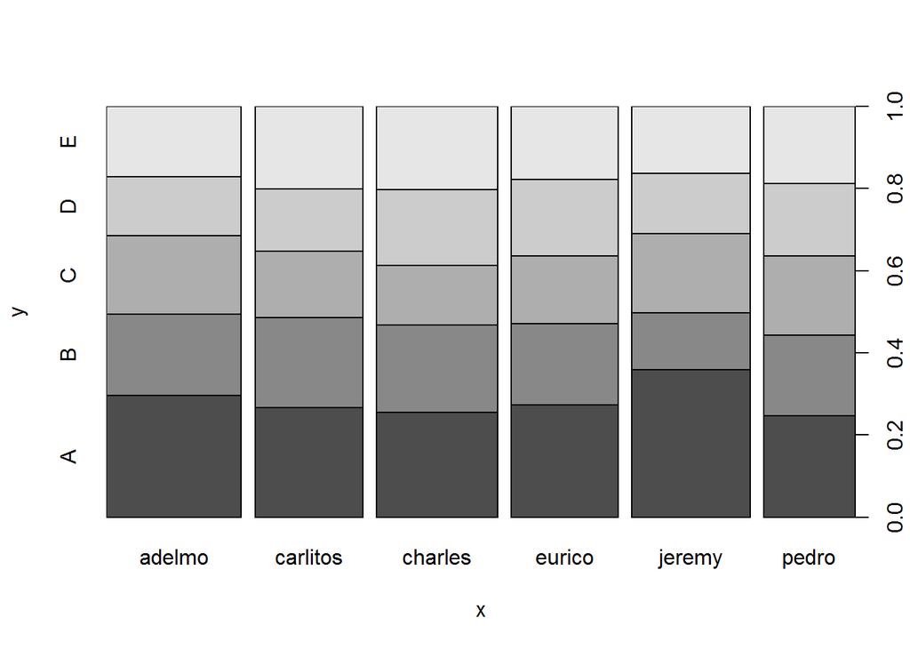

All the users and all the classes are represented almost equally.

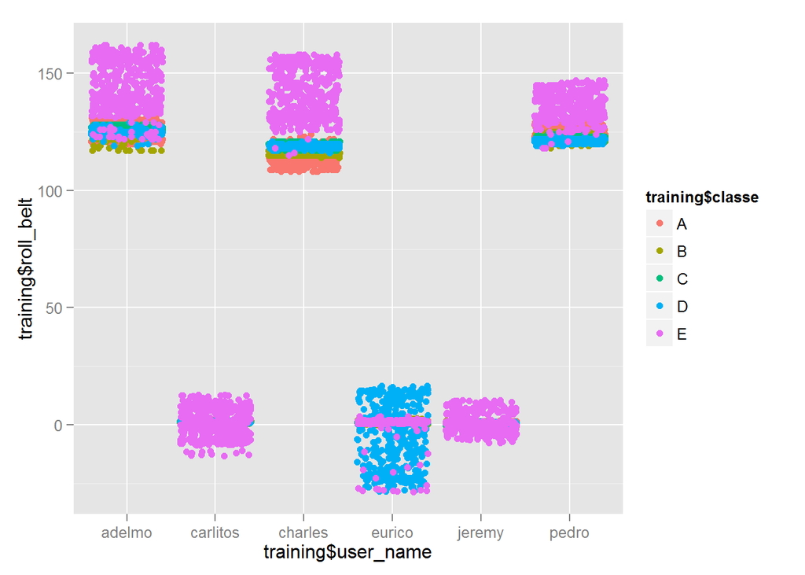

Two distinct user groups appearing. These measure distinct values for roll_belt. For every classe, the higher the variation, the worse the classe (D, E)

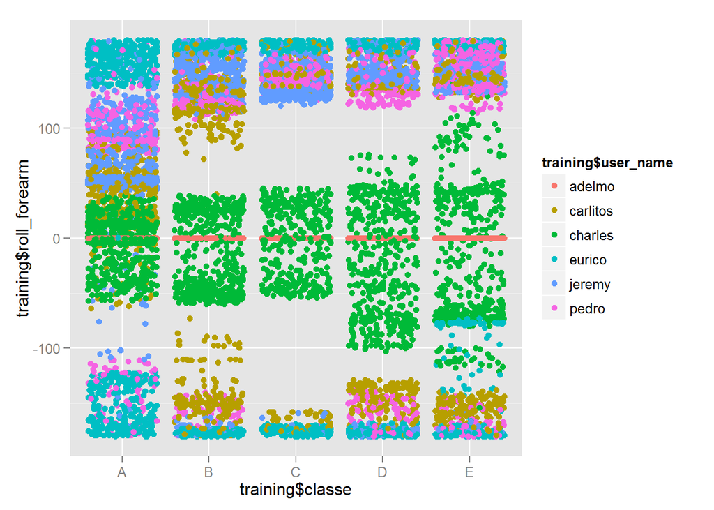

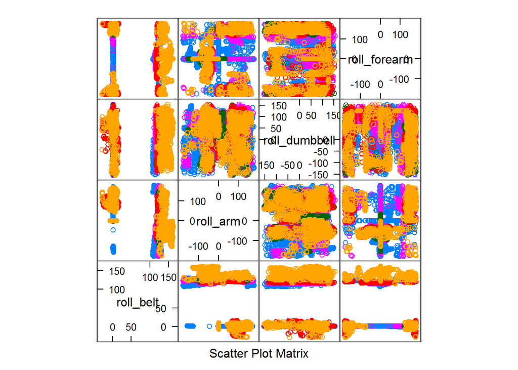

After analysing the various plots, I couldnt come up with any single variable which was overwhelmingly supporting the data, so based on my prior understanding of the data set and what it is used for, I used my judgement call to select the features which were data collected from the devices. This excludes the timeseries information present in the data set.

```r
fmla1 <- as.formula(paste("classe ~ ", paste(colnames(training[,7:58]), collapse= "+")))
```

## Model building

### Classification Tree

Since this is a classification problem, my first idea was to try fit a classification tree to this problem. It is a simple model that is computationally efficient. If the output at the end of model is accurate enough, we dont have to use more complicated analysis.

```r
modelFit <- train(fmla1, method="rpart", data=training)
modelFit
```

```
## CART
##
## 13453 samples
##    58 predictor
##     5 classes: 'A', 'B', 'C', 'D', 'E'
##
## No pre-processing
## Resampling: Bootstrapped (25 reps)
##
## Summary of sample sizes: 13453, 13453, 13453, 13453, 13453, 13453, ...
##
## Resampling results across tuning parameters:
##
##   cp          Accuracy   Kappa       Accuracy SD  Kappa SD
##   0.03283799  0.5005787  0.34480155  0.04376198   0.07174208
##   0.05937164  0.4161888  0.20884216  0.06317776   0.10493976
##   0.11472514  0.3177575  0.04937642  0.04024362   0.06175025
##
## Accuracy was used to select the optimal model using  the largest value.
## The final value used for the model was cp = 0.03283799.
```

But as seen from the results of this model, the accuracy is quite low (50% only), even in the training set, let alone the test set.

### Random forest

Fit the random forest model to the model. I have put in a tree limit of 100 (based on recommendations from the course forums). Without this limit, the model was taking very long to run. I found that with a 100 tree limit, my accuracy was already very high.

```r
modelFitRF <- train(fmla1, method="rf", data=training, ntree=100)
modelFitRF
```

```
## Random Forest
##
## 13453 samples
##    58 predictor
##     5 classes: 'A', 'B', 'C', 'D', 'E'
##
## No pre-processing
## Resampling: Bootstrapped (25 reps)
##
## Summary of sample sizes: 13453, 13453, 13453, 13453, 13453, 13453, ...
##
## Resampling results across tuning parameters:
##
##   mtry  Accuracy   Kappa      Accuracy SD  Kappa SD
##    2    0.9868927  0.9834156  0.001986933  0.002509095
##   27    0.9886761  0.9856721  0.001346896  0.001706949
##   52    0.9812548  0.9762833  0.003353363  0.004232479
##
## Accuracy was used to select the optimal model using  the largest value.
## The final value used for the model was mtry = 27.
```

Since the in sample error rate was very low this time. I decided to validate this against the test set.

```r
preds <- predict(modelFitRF, newdata=testing)
confusionMatrix(preds, testing$classe)
```

```
## Confusion Matrix and Statistics
##
##           Reference
## Prediction    A    B    C    D    E
##          A 1637    4    0    0    0
##          B    3 1109    5    0    1
##          C    1    2  995   11    0
##          D    0    0    5  931    4
##          E    0    0    0    2 1053
##
## Overall Statistics
##
##                Accuracy : 0.9934
##                  95% CI : (0.991, 0.9953)
##     No Information Rate : 0.2847
##     P-Value [Acc > NIR] : < 2.2e-16
##
##                   Kappa : 0.9917
##  Mcnemar's Test P-Value : NA
##
## Statistics by Class:
##
##                      Class: A Class: B Class: C Class: D Class: E
## Sensitivity            0.9976   0.9946   0.9900   0.9862   0.9953
## Specificity            0.9990   0.9981   0.9971   0.9981   0.9996
## Pos Pred Value         0.9976   0.9919   0.9861   0.9904   0.9981
## Neg Pred Value         0.9990   0.9987   0.9979   0.9973   0.9989
## Prevalence             0.2847   0.1935   0.1744   0.1638   0.1836
## Detection Rate         0.2841   0.1924   0.1727   0.1615   0.1827
## Detection Prevalence   0.2847   0.1940   0.1751   0.1631   0.1831
## Balanced Accuracy      0.9983   0.9963   0.9936   0.9922   0.9974
```

The confusion matrix showed an over accuracy of greater than 99% (very low out of sample error) which was sufficient to instil confidence in these results and that this model was working and could be applied to the validation set.

## Model Validation

From here on, the process is simple. I loaded the validation set of 20 test cases provided, and performed the same cleaning operations on that set before fitting the model to it.

```r
pml_validation_data  <- read.table('pml-testing.csv', header=T, sep=',')
pml_validation_data$X <- NULL # remove the first column which is just a row number
pml_validation_data_excNewWindow_removeCols <- pml_validation_data
colNamesToBeRemoved  <-  list('kurtosis_', 'min_','max_','stddev_','amplitude_','skewness_','var_','avg_')
for (i in 1:length(colNamesToBeRemoved)){pml_validation_data_excNewWindow_removeCols  <- pml_validation_data_excNewWindow_removeCols[,-grep(colNamesToBeRemoved[i],names(pml_validation_data_excNewWindow_removeCols))]}
validationPreds <- predict(modelFitRF, newdata=pml_validation_data_excNewWindow_removeCols)
validationPreds
```

```
##  [1] B A B A A E D B A A B C B A E E A B B B
## Levels: A B C D E
```

This result was then uploaded to the Course website submission page. Happy to say that I got all 20/20 predictions correct using the model above :)